# Seasonality decomposition using decompose and stl

classicaholic

2015년 8월 6일

**Trend/seasonality decomposition을 위한 function 2종류**

1. decompose의 특징
   - additive와 multiplicative를 모두 지원한다. 둘의 차이점은 아래의 그림 참고. (multiplicative는 stl가 기본 지원하지 않으므로 특히 유용)

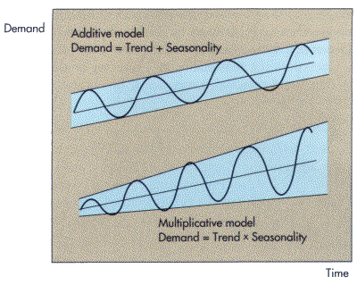

   - Classical Seasonality Decomposition by Moving Average이며, 가장 기초적이고 기본적인 방법
2. stl의 특징
   - smoothing 기능을 지원 (t.window=n)
   - 그 외에도 다양한 옵션을 지원하므로 매뉴얼을 참고할 것
   - observation data에 log / exp를 사용함으로써 multiplicative 방식의 수치를 얻을 수 있으나, seasonality가 매우 밋밋하여 seasonality 편차가 큰 경우에는 부적절 (e.g. 대형마트에서의 주중 vs 주말 sales 등)
   - log / exp를 씌워서 multiplicative 방식으로 적용할 경우 observation이 0보다 커야 함 (0에 log를 씌우면 에러나니까 ㅎ)
   - log / exp로 multiplicative가 된다면, sqrt / 제곱으로는 비슷한 결과를 얻을 수 있지 않나? (classicaholic’s note on 2014.10.05)
   - decompose를 이용하여 얻은 trend에 다시 stl에 적용하는 방식으로도 활용할 수 있을 것으로 보임

**Seasonality 분석 및 활용 시 주의할 점**

1. Seasonality 분석 시 __최소 4년치 이상__의 데이터 필요
2. 데이터의 뒷부분 기준으로 개수를 세어서 seasonality가 나오는 점에 주의 (무슨 말이냐 하면, 2007년 1월부터 2013년 9월까지의 data가 있을 경우, seasonality로 추출된 값은 1월부터 12월까지의 seasonality가 아니라, 10월부터 9월까지의 seasonality로 계산된다)

이제 분석을 시작해보자. 먼저 샘플 데이터를 불러온다.

```r
sample.data <- read.csv('sample data.csv')
```

frequency는 원래 365(일), 12(월), 4(분기) 등으로 지정하지만, 아래의 경우, 1주일 seasonality를 분석하기 위해 7을 지정했다. 참고로, 7은 기본 옵션에는 없는 숫자이지만 분석에는 지장이 없다.

```r
temp.ts <- ts(sample.data$sales.POS.amount, start=c(2010,1,1), frequency=7)
```

NA가 있을 경우 0으로 치환해준다.

```r
temp.ts[is.na(temp.ts)] <- 0
```

decompose / additive 방식으로 해보자. decompose에서는 달리 지정할 옵션이 많지 않다.

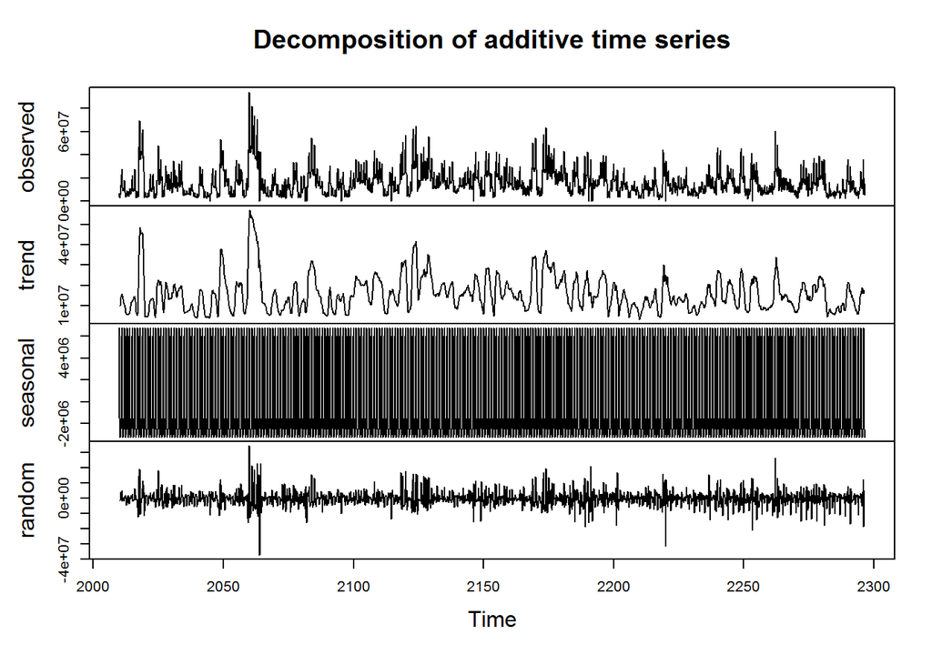

```r
temp.decompose <- decompose(temp.ts, 'additive')
plot(temp.decompose)
```

decompose / multiplicative 방식으로 해보자. 바뀐 건 거의 없다.

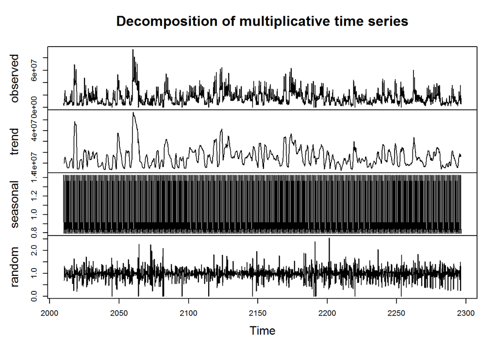

```r
temp.decompose <- decompose(temp.ts, 'multiplicative')
plot(temp.decompose)
```

아래는 decompose의 output object를 data.frame으로 변환시켜서 저장하는 방법이다. 참고로, stl의 output object와 저장 방식이 달라서 data.frame으로 전환하는 방법에 약간 차이가 있다.

```r
temp.output <- data.frame(temp.decompose[2:4])
temp.output <- as.data.frame(as.ts(temp.output, 'matrix'))
names(temp.output) <- c('decompose.seasonal', 'decompose.trend', 'decompose.random')
write.csv(temp.output, 'example.csv')
```

아래는 stl / additive 방식이다.

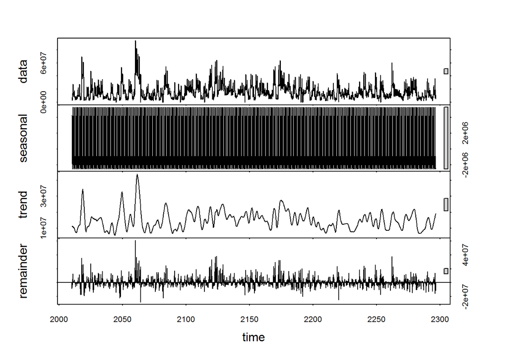

```r
temp.stl<- stl(temp.ts, s.window='per', t.window=30, robust=TRUE)
plot(temp.stl)
```

```r
temp.output <- as.data.frame(temp.stl$time.series)
names(temp.output) <- c('stl.seasonal', 'stl.trend', 'stl.remainder')
write.csv(temp.output, 'example.csv')
```

아래는 stl / multiplicative(log/exp) 방식이다.

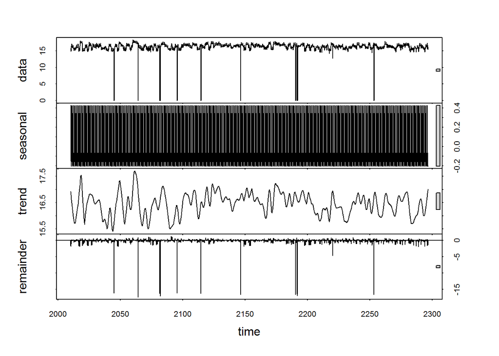

```r
temp.log <- log(sample.data$sales.POS.amount) # 데이터에 로그를 취한다
temp.log.ts <- ts(temp.log, start=c(2010,1,1), frequency=7)
temp.log.ts[is.na(temp.log.ts)] <- 0
temp.stl<- stl(temp.log.ts, s.window='per', t.window=30, robust=TRUE)
plot(temp.stl)
```

```r
temp.output <- as.data.frame(temp.stl$time.series)
temp.output <- exp(temp.output) # 분석된 데이터에 exp를 취한다
names(temp.output) <- c('stl.seasonal', 'stl.trend', 'stl.remainder')
write.csv(temp.output, 'example.csv')
```